# EP11-respuesta-equipo-1

Equipo 1

2026-01-21

# EP10

```r
library(car)
library(dplyr)
library(pROC)
library(ggpubr)
library(leaps)
library(caret)
set.seed(86949)

datos <- read.csv2("EP09 Datos.csv")

# Crear variables IMC y EN
datos$IMC <- datos$Weight / ((datos$Height/100)**2)
datos$EN <- ifelse(datos$IMC >= 23.2, "Sobrepeso", "No sobrepeso")
datos$EN <- factor(datos$EN, levels = c("No sobrepeso", "Sobrepeso"))

# Separar por clase
personas_sobrepeso <- datos %>% filter(EN == "Sobrepeso")
personas_no_sobrepeso <- datos %>% filter(EN == "No sobrepeso")

# Seleccionar muestras de sobrepeso de 75 de cada uno
muestra_sobrepeso <- personas_sobrepeso %>% sample_n(75)
muestra_no_sobrepeso <- personas_no_sobrepeso %>% sample_n(75)

# Crear conjunto de entrenamiento (100 datos: 50 SP + 50 NoSP)
train_sobrepeso <- muestra_sobrepeso %>% sample_n(50)
train_no_sobrepeso <- muestra_no_sobrepeso %>% sample_n(50)

train <- bind_rows(train_sobrepeso, train_no_sobrepeso)
train <- train[sample(nrow(train)), ]

# Crear conjunto de prueba (50 datos: 25 SP + 25 NoSP)
# Usamos anti_join para tomar los que NO se usaron en train
test_sobrepeso <- muestra_sobrepeso %>% anti_join(train_sobrepeso)
test_no_sobrepeso <- muestra_no_sobrepeso %>% anti_join(train_no_sobrepeso)

test <- bind_rows(test_sobrepeso, test_no_sobrepeso)
test <- test[sample(nrow(test)), ]

cat("Dimensiones train:", nrow(train), "- Distribución:", table(train$EN), "\n")
```

```
## Dimensiones train: 100 - Distribución: 50 50
```

```r
cat("Dimensiones test:", nrow(test), "- Distribución:", table(test$EN), "\n")
```

```
## Dimensiones test: 50 - Distribución: 25 25
```

### Busqueda de predictores

Usando el paquete leaps, se realiza una busqueda exhaustiva para seleccionar de dos a ocho predictores para estimar la variable Peso (Weight) sin considerar IMC ni EN.

```r
# Eliminar IMC y EN
train_no_imc_en <- train[, !(names(train) %in% c("IMC", "EN"))]

# Ajuste exhaustivo entre 2 y 8 predictores
exhaustivo <- regsubsets(
  Weight ~ .,
  data = train_no_imc_en,
  nvmax = 8,
  method = "exhaustive"
)

# Resumen del modelo
res <- summary(exhaustivo)

# Índice del modelo con mayor R2 ajustado
best_index <- which.max(res$adjr2)

# Predictores del mejor modelo
best_predictors <- names(coef(exhaustivo, best_index))[-1]

best_predictors
```

```
## [1] "Biacromial.diameter" "Chest.Girth"         "Waist.Girth"
## [4] "Hip.Girth"           "Thigh.Girth"         "Bicep.Girth"
## [7] "Calf.Maximum.Girth"  "Height"
```

### Construccion modelo RLM

Usando el paquete caret, se construye un modelo de regresión lineal múltiple con los predictores elegidos anteriormente y evaluarlo usando 1000 muestras para bootstraping, 10 veces la muestra original.

```r
formula_best <- as.formula(
  paste("Weight ~", paste(best_predictors, collapse = " + "))
)

ctrl <- trainControl(
  method = "boot",
  number = 1000
)

modelo_lm <- train(
  formula_best,
  data = train_no_imc_en,
  method = "lm",
  trControl = ctrl
)

modelo_lm
```

```
## Linear Regression
##
## 100 samples
##   8 predictor
##
## No pre-processing
## Resampling: Bootstrapped (1000 reps)
## Summary of sample sizes: 100, 100, 100, 100, 100, 100, ...
## Resampling results:
##
##   RMSE      Rsquared   MAE
##   2.151818  0.9736101  1.718414
##
## Tuning parameter 'intercept' was held constant at a value of TRUE
```

```r
summary(modelo_lm$finalModel)
```

```
##
## Call:
## lm(formula = .outcome ~ ., data = dat)
##
## Residuals:
##     Min      1Q  Median      3Q     Max
## -3.6870 -1.3786 -0.1909  1.3751  6.7679
##
## Coefficients:
##                       Estimate Std. Error t value Pr(>|t|)
## (Intercept)         -122.63138    5.00942 -24.480  < 2e-16 ***
## Biacromial.diameter    0.58744    0.13195   4.452 2.41e-05 ***
## Chest.Girth            0.17385    0.06817   2.550  0.01244 *
## Waist.Girth            0.27449    0.04387   6.258 1.26e-08 ***
## Hip.Girth              0.22522    0.07586   2.969  0.00382 **
## Thigh.Girth            0.43813    0.09173   4.776 6.80e-06 ***
## Bicep.Girth            0.43772    0.14085   3.108  0.00252 **
## Calf.Maximum.Girth     0.28624    0.10787   2.653  0.00940 **
## Height                 0.35587    0.03298  10.791  < 2e-16 ***
## ---
## Signif. codes:  0 '***' 0.001 '**' 0.01 '*' 0.05 '.' 0.1 ' ' 1
##
## Residual standard error: 1.949 on 91 degrees of freedom
## Multiple R-squared:  0.9786, Adjusted R-squared:  0.9767
## F-statistic: 520.8 on 8 and 91 DF,  p-value: < 2.2e-16
```

### Confiabilidad del modelo

Ahora verificamos la confiabilidad del modelo:

1. La variable de salida (peso) es una variable cuantitativa y continua, ya que mide una magnitud fisica.
2. Los predictores son cuantitativos, ya que son mediciones fisicas de un objeto real.
3. Los predictores no son constantes.
4. Cada predictor debe estar relacionado linealmente con la respuesta.

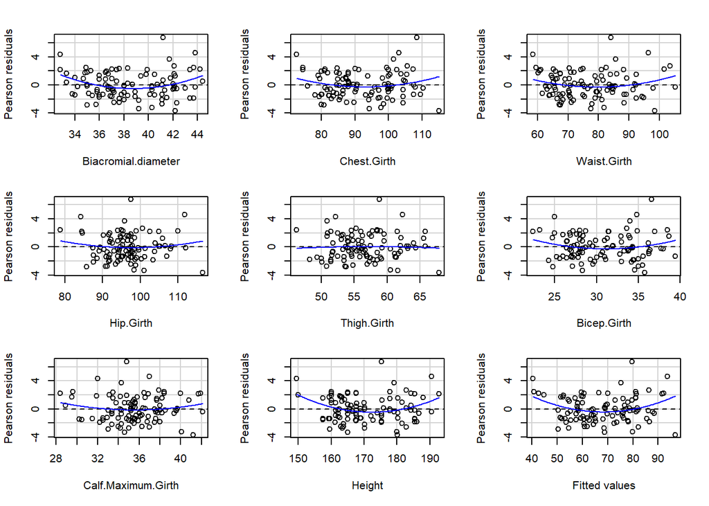

```
##                     Test stat Pr(>|Test stat|)
## Biacromial.diameter    2.7828         0.006566 **
## Chest.Girth            1.5316         0.129122
## Waist.Girth            1.9508         0.054186 .
## Hip.Girth              0.9337         0.352965
## Thigh.Girth           -0.2334         0.815952
## Bicep.Girth            1.5583         0.122683
## Calf.Maximum.Girth     1.2476         0.215405
## Height                 2.6465         0.009599 **
## Tukey test             2.7742         0.005533 **
## ---
## Signif. codes:  0 '***' 0.001 '**' 0.01 '*' 0.05 '.' 0.1 ' ' 1
```

```r
modelo_lm_base <- lm(
  formula_best,
  data = train_no_imc_en
)
residualPlots(modelo_lm_base)
```

Procedemos a obtener una representación gráfica de posibles valores atípicos, el apalancamiento y la distancia de Cook.

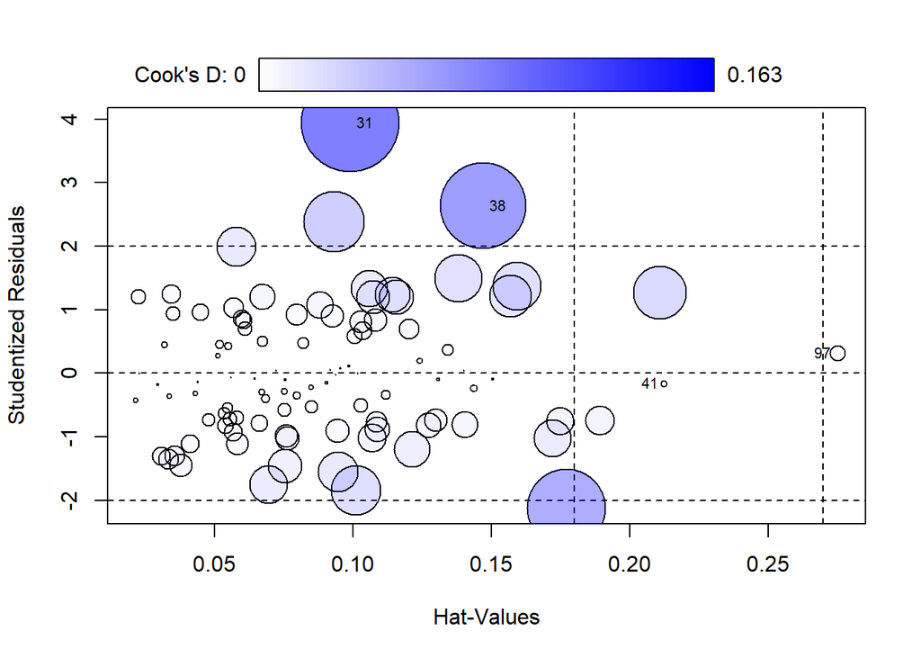

```
##       StudRes        Hat        CookD
## 31  3.9389848 0.09893925 0.1632545718
## 38  2.6363152 0.14692525 0.1248401785
## 41 -0.1659789 0.21249414 0.0008348764
## 97  0.3185545 0.27506268 0.0043208156
```

```r
influencePlot(modelo_lm_base, id = list(cex = 0.7))
```

La curvatura que vimos en el gráfico de ResidualPlots puede no ser real, sino una consecuencia de este caso atípico. Procedemos a eliminar el dato con mayor apalancamiento.

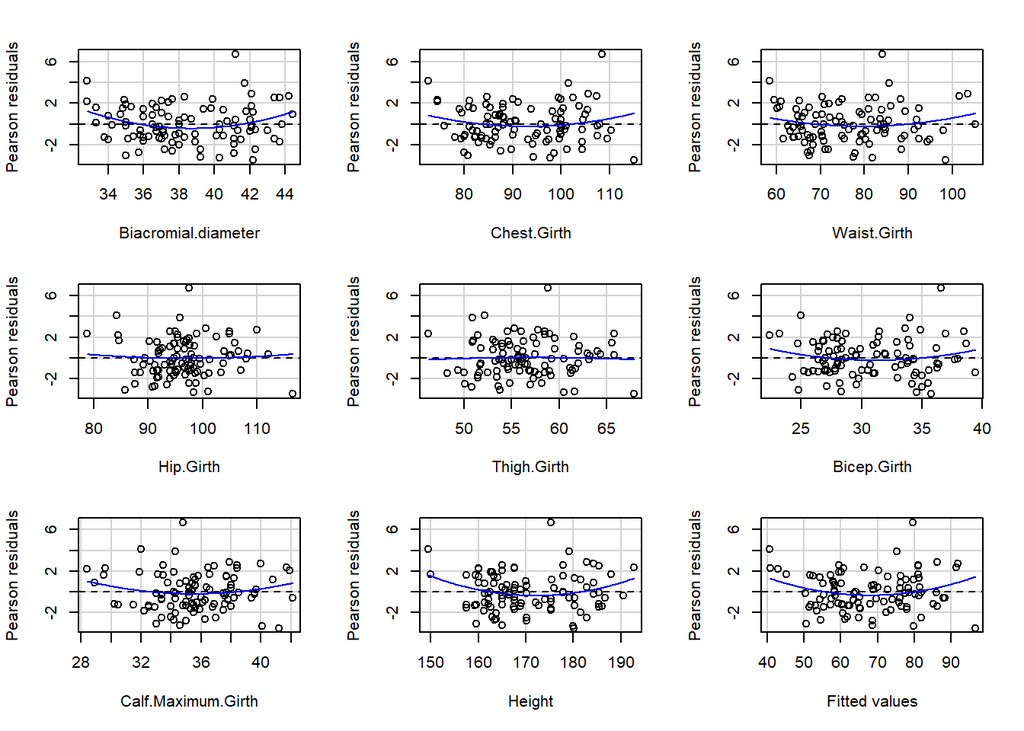

```
##                     Test stat Pr(>|Test stat|)
## Biacromial.diameter    2.3897          0.01900 *
## Chest.Girth            1.3572          0.17820
## Waist.Girth            1.5338          0.12866
## Hip.Girth              0.3796          0.70514
## Thigh.Girth           -0.2282          0.82002
## Bicep.Girth            1.3095          0.19377
## Calf.Maximum.Girth     1.5112          0.13432
## Height                 2.0359          0.04477 *
## Tukey test             2.0604          0.03936 *
## ---
## Signif. codes:  0 '***' 0.001 '**' 0.01 '*' 0.05 '.' 0.1 ' ' 1
```

```r
# Eliminar observaciones influyentes
outliers <- c(97, 31)
train_limpio <- train_no_imc_en[-outliers, ]

# Reajustar modelo
modelo_arreglado <- lm(
  formula(modelo_lm_base),
  data = train_limpio
)

# Diagnóstico
residualPlots(modelo_arreglado)
```

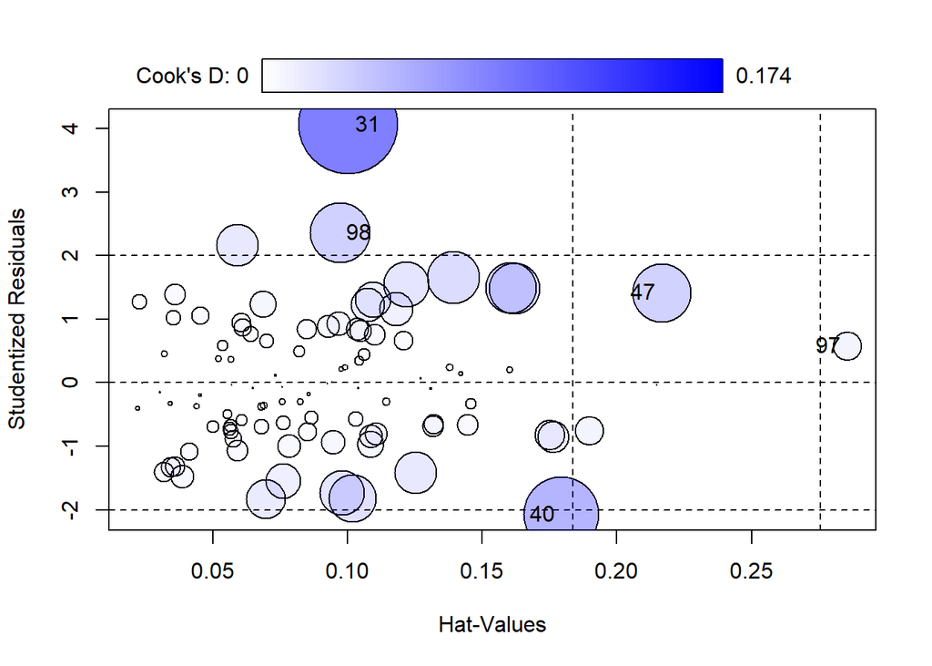

```
##       StudRes        Hat      CookD
## 31  4.0643212 0.10024911 0.17413567
## 98  2.3600473 0.09708071 0.06329030
## 97  0.5775415 0.28562906 0.01493024
## 40 -2.0723299 0.17934666 0.10055942
## 47  1.4156131 0.21672875 0.06092273
```

```r
influencePlot(modelo_arreglado)
```

Podemos apreciar que la eliminación de este caso corrigió un poco el problema de linealidad detectado previamente, pero no logra satisfacer completamente la condicion, por lo que no consideramos la eliminacion de los datos.

5. La distibución de los residuos debe ser cercana a la normal centrada en cero.
6. La variabilidad de los residuos debe ser aproximadamente constante (homocedasticidad)

```r
ncvTest(modelo_arreglado)
```

```
## Non-constant Variance Score Test
## Variance formula: ~ fitted.values
## Chisquare = 0.7412921, Df = 1, p = 0.38925
```

El p-value es 0.389, lo que es mayor que el nivel de significancia (0.05), por lo que no existe evidencia suficiente para rechazar la hipótesis de homocedasticidad. Por lo tanto, se asume que la variabilidad de los residuos es aproximadamente constante.

7. Los residuos deben ser independientes entre sí.

```r
durbinWatsonTest(modelo_arreglado)
```

```
##  lag Autocorrelation D-W Statistic p-value
##    1       0.1274528      1.735388   0.174
##  Alternative hypothesis: rho != 0
```

Como el p-value es 0.174, mayor al nivel de significancia (0.05), no existe evidencia suficiente para rechazar la independencia entre los residuos. Además el estadístico D-W tiene un valor de 1.735 y un valor cercano a 2 indica ausencia total de autocorrelación.

8. No debe existir multicolinealidad.

```r
vif(modelo_arreglado)
```

```
## Biacromial.diameter         Chest.Girth         Waist.Girth           Hip.Girth
##            4.135606           11.774914            5.911329            5.901114
##         Thigh.Girth         Bicep.Girth  Calf.Maximum.Girth              Height
##            3.931080            8.138065            2.480435            2.610423
```

Se presentan valores que representan una multicolinealidad crítica, para ser específicos Chest.Girth. Se tiene tambien predicotres con multicolinealidad moderada como Hip.Girth, Waist.Girth y Bicep.Girth. Los demás predictores tienen una multicolinealidad aceptable. Se puede decir que Chest.Girth no presenta información significativa al modelo.

A continuación, se pondrá a prueba el modelo con los datos no utilizados para construirlo para evaluar su poder predictivo.

```r
test_no_imc_en <- test[, !(names(test) %in% c("IMC", "EN"))]
pred_test <- predict(modelo_lm, newdata = test_no_imc_en)

res_test <- postResample(
  pred = pred_test,
  obs  = test_no_imc_en$Weight
)

modelo_lm_base$results
```

```r
res_test
```

```
##      RMSE  Rsquared       MAE
## 2.2376583 0.9724443 1.6408040
```

El modelo fue entrenado utilizando validación por bootstrapping (1000 remuestreos) sobre el conjunto de entrenamiento mediante el paquete caret. Posteriormente, se evaluó su desempeño predictivo en un conjunto de prueba independiente. La similitud entre las métricas obtenidas en el bootstrap y en el conjunto de prueba indica una adecuada capacidad de generalización del modelo.

#### Haciendo un poco de investigación sobre el paquete caret, en particular cómo hacer Recursive Feature Elimination (RFE), construir un modelo de regresión lineal múltiple para predecir la variable IMC que incluya entre 10 y 20 predictores, seleccionando el conjunto de variables que maximice R2 y que use cinco repeticiones de validación cruzada de cinco pliegues para evitar el sobreajuste (obviamente no se debe considerar las variables Peso, Estatura ni estado nutricional –Weight, Height, EN respectivamente).

```r
train_rfe <- train %>%
  select(-Weight, -Height, -EN)

x <- train_rfe %>% select(-IMC)
y <- train_rfe$IMC

ctrl_rfe <- rfeControl(
  functions = lmFuncs,        # regresión lineal
  method = "repeatedcv",
  number = 5,                 # 5 folds
  repeats = 5,                # 5 repeticiones
  verbose = FALSE
)

rfe_model <- rfe(
  x = x,
  y = y,
  sizes = 10:20,              # ENTRE 10 Y 20
  rfeControl = ctrl_rfe,
  metric = "Rsquared"
)

formula_rfe <- as.formula(
  paste("IMC ~", paste(predictors(rfe_model), collapse = " + "))
)

modelo_final_rfe <- train(
  formula_rfe,
  data = train_rfe,
  method = "lm",
  trControl = trainControl(
    method = "repeatedcv",
    number = 5,
    repeats = 5
  )
)

summary(modelo_final_rfe$finalModel)
```

```
##
## Call:
## lm(formula = .outcome ~ ., data = dat)
##
## Residuals:
##      Min       1Q   Median       3Q      Max
## -2.00130 -0.65265  0.04191  0.67429  2.63718
##
## Coefficients:
##                      Estimate Std. Error t value Pr(>|t|)
## (Intercept)         -10.47856    2.58901  -4.047 0.000114 ***
## Gender               -2.24233    0.57289  -3.914 0.000182 ***
## Ankles.diameter      -0.34857    0.19079  -1.827 0.071217 .
## Wrists.diameter       0.31580    0.25466   1.240 0.218355
## Forearm.Girth         0.19924    0.14876   1.339 0.184039
## Thigh.Girth           0.22127    0.04183   5.290 9.37e-07 ***
## Elbows.diameter      -0.07094    0.20061  -0.354 0.724510
## Knees.diameter        0.07506    0.14875   0.505 0.615135
## Bicep.Girth           0.17013    0.08711   1.953 0.054095 .
## Biiliac.diameter     -0.12380    0.05842  -2.119 0.037012 *
## Wrist.Minimum.Girth  -0.03924    0.20509  -0.191 0.848732
## Biacromial.diameter   0.13595    0.07344   1.851 0.067601 .
## Waist.Girth           0.16484    0.02052   8.031 4.89e-12 ***
## Knee.Girth           -0.10578    0.08911  -1.187 0.238498
## Calf.Maximum.Girth    0.08043    0.06660   1.208 0.230493
## ---
## Signif. codes:  0 '***' 0.001 '**' 0.01 '*' 0.05 '.' 0.1 ' ' 1
##
## Residual standard error: 1.018 on 85 degrees of freedom
## Multiple R-squared:   0.88,  Adjusted R-squared:  0.8603
## F-statistic: 44.54 on 14 and 85 DF,  p-value: < 2.2e-16
```

### Confiabilidad del modelo

Ahora verificamos la confiabilidad del modelo:

1. La variable de salida (IMC) es una variable cuantitativa y continua, ya que es una relación entre magnitudes físicas.
2. Los predictores son cuantitativos, ya que son mediciones fisicas de un objeto real, a excepción de Gender el cual es dicotómico.
3. Los predictores no son constantes.
4. Cada predictor debe estar relacionado linealmente con la respuesta.

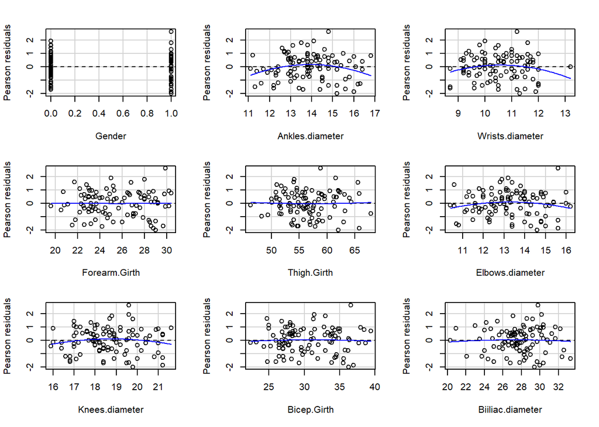

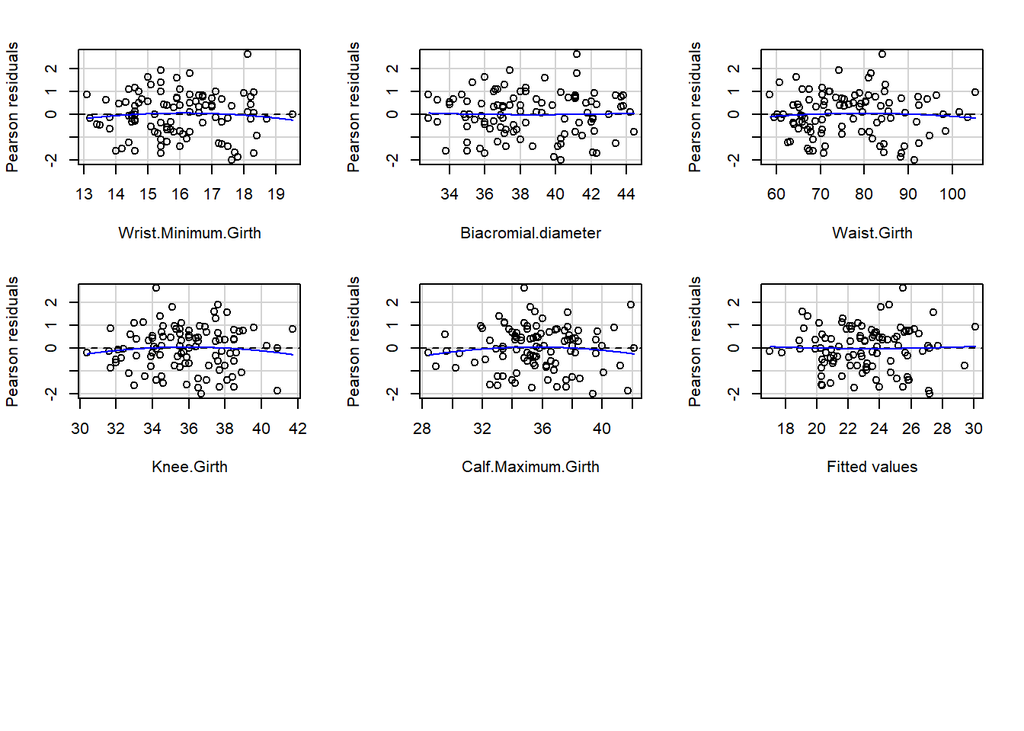

```
##                     Test stat Pr(>|Test stat|)
## Gender                -0.3346          0.73879
## Ankles.diameter       -2.1544          0.03407 *
## Wrists.diameter       -1.5201          0.13224
## Forearm.Girth          0.0541          0.95699
## Thigh.Girth            0.1822          0.85589
## Elbows.diameter       -1.2716          0.20701
## Knees.diameter        -1.0805          0.28302
## Bicep.Girth           -0.2459          0.80634
## Biiliac.diameter      -0.2966          0.76748
## Wrist.Minimum.Girth   -0.6100          0.54350
## Biacromial.diameter    0.1952          0.84575
## Waist.Girth           -0.4947          0.62214
## Knee.Girth            -0.6651          0.50783
## Calf.Maximum.Girth    -0.8211          0.41394
## Tukey test             0.1969          0.84394
## ---
## Signif. codes:  0 '***' 0.001 '**' 0.01 '*' 0.05 '.' 0.1 ' ' 1
```

```r
modelo_lm_base_rfe <- lm(
  formula_rfe,
  data = train_rfe
)
residualPlots(modelo_lm_base_rfe)
```

Se puede ver que los predictores seleccionados no presentan curvatura, a excepción de Ankles.diameter, el cual presenta una leve curvatura significativa. Este predictor podría no estra relacionado linealmente con el IMC.

Procedemos a obtener una representación gráfica de posibles valores atípicos, el apalancamiento y la distancia de Cook.

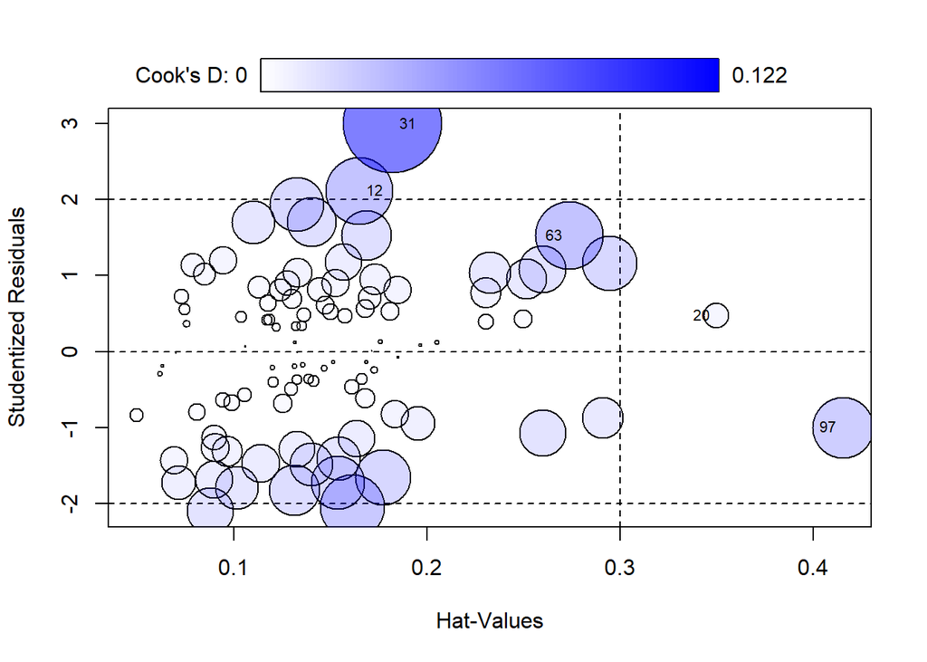

```
##       StudRes       Hat       CookD
## 12  2.1153223 0.1650112 0.056636315
## 31  2.9961397 0.1823290 0.121998363
## 97 -0.9970388 0.4153454 0.047083976
## 20  0.4771768 0.3498477 0.008243188
## 63  1.5289766 0.2735409 0.057774954
```

```r
influencePlot(modelo_lm_base_rfe, id = list(cex = 0.7))
```

Se presentan 5 valores atipicos, el dato 97 posee una nivel de apalancamiento superior al umbral de 0,3 aprox, tambien todos poseen una distancia de Cook menor al umbral de 0,122. La curvatura que vimos en el gráfico de ResidualPlots puede no ser real, sino una consecuencia de este caso atípico. Procedemos a eliminar el dato con mayor apalancamiento.

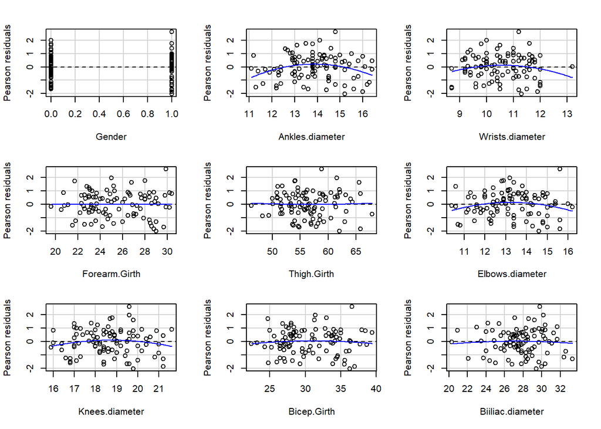

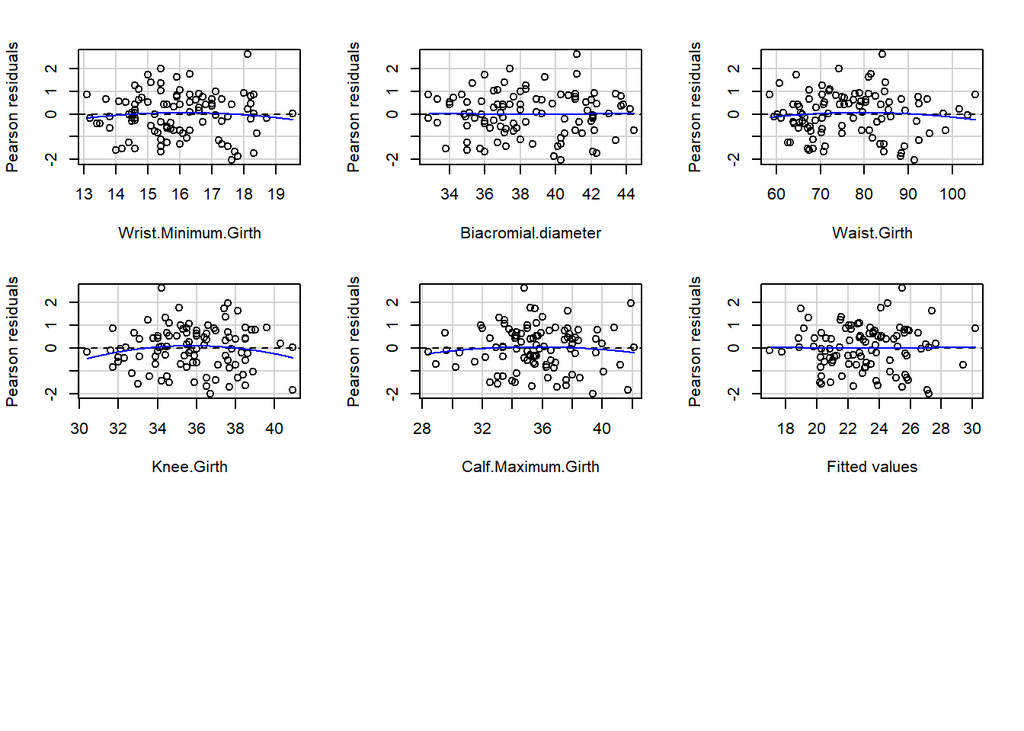

```
##                     Test stat Pr(>|Test stat|)
## Gender                 0.3419         0.733321
## Ankles.diameter       -2.7038         0.008332 **
## Wrists.diameter       -1.3910         0.167992
## Forearm.Girth         -0.0233         0.981476
## Thigh.Girth            0.1923         0.848008
## Elbows.diameter       -1.6799         0.096792 .
## Knees.diameter        -1.2621         0.210495
## Bicep.Girth           -0.4761         0.635273
## Biiliac.diameter      -0.4024         0.688458
## Wrist.Minimum.Girth   -0.6037         0.547693
## Biacromial.diameter    0.0988         0.921540
## Waist.Girth           -0.7804         0.437385
## Knee.Girth            -1.2052         0.231591
## Calf.Maximum.Girth    -0.6818         0.497262
## Tukey test             0.1042         0.917040
## ---
## Signif. codes:  0 '***' 0.001 '**' 0.01 '*' 0.05 '.' 0.1 ' ' 1
```

```r
# Eliminar observaciones influyentes
outliers_rfe <- c(97, 20)
train_limpio_rfe <- train_rfe[-outliers, ]

# Reajustar modelo
modelo_arreglado_rfe <- lm(
  formula(modelo_lm_base_rfe),
  data = train_limpio_rfe
)

# Diagnóstico
residualPlots(modelo_arreglado_rfe)
```

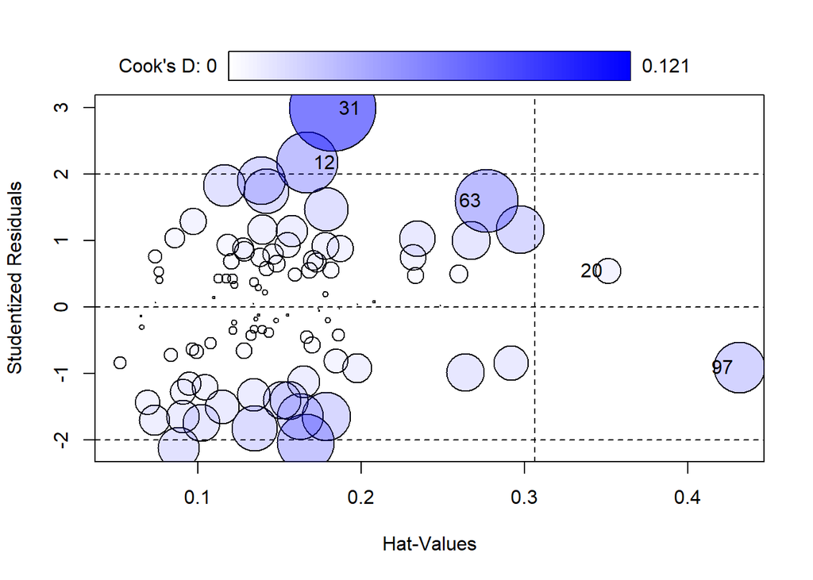

```
##       StudRes       Hat      CookD
## 12  2.1697548 0.1670254 0.06024218
## 31  2.9839897 0.1826416 0.12111129
## 97 -0.9128787 0.4313853 0.04223329
## 20  0.5433276 0.3511985 0.01074427
## 63  1.5978077 0.2766356 0.06389367
```

```r
influencePlot(modelo_arreglado_rfe)
```

Podemos ver que no mejoró la curvatura para Ankles.diameter, entonces no consideramos la eliminación.

5. La distibución de los residuos debe ser cercana a la normal centrada en cero.
6. La variabilidad de los residuos debe ser aproximadamente constante (homocedasticidad)

```r
ncvTest(modelo_lm_base_rfe)
```

```
## Non-constant Variance Score Test
## Variance formula: ~ fitted.values
## Chisquare = 2.386965, Df = 1, p = 0.12235
```

El p-value es 0.122, lo que es mayor que el nivel de significancia (0.05), por lo que no existe evidencia suficiente para rechazar la hipótesis de homocedasticidad. Por lo tanto, se asume que la variabilidad de los residuos es aproximadamente constante.

7. Los residuos deben ser independientes entre sí.

```r
durbinWatsonTest(modelo_lm_base_rfe)
```

```
##  lag Autocorrelation D-W Statistic p-value
##    1      -0.1435852      2.284461   0.146
##  Alternative hypothesis: rho != 0
```

Como el p-value es 0.146, mayor al nivel de significancia (0.05), no existe evidencia suficiente para rechazar la independencia entre los residuos. Además el estadístico D-W tiene un valor de 2.284 y un valor cercano a 2 indica ausencia total de autocorrelación.

8. No debe existir multicolinealidad.

```r
vif(modelo_lm_base_rfe)
```

```
##              Gender     Ankles.diameter     Wrists.diameter       Forearm.Girth
##            7.837724            5.774350            5.420532           15.548844
##         Thigh.Girth     Elbows.diameter      Knees.diameter         Bicep.Girth
##            3.043152            7.242299            3.860622           11.666708
##    Biiliac.diameter Wrist.Minimum.Girth Biacromial.diameter         Waist.Girth
##            1.918165            8.125467            4.771485            4.929505
##          Knee.Girth  Calf.Maximum.Girth
##            4.037803            3.292339
```

Se presentan valores que representan una multicolinealidad crítica, para ser específicos Bicep.Girth y Forearm.Girth. Se tiene tambien predicotres con multicolinealidad moderada como Wrists.diameter, Ankles.diameter, Elbows.diameter, Gender, Wrist.Minimum.Girth. Los demás predictores tienen una multicolinealidad aceptable. Se puede decir que Bicep.Girth, Forearm.Girth no presenta información significativa al modelo.

A continuación, se pondrá a prueba el modelo con los datos no utilizados para construirlo para evaluar su poder predictivo.

```r
test_rfe <- test %>%
  select(-Weight, -Height, -EN)

pred_test <- predict(modelo_lm_base_rfe, newdata = test_rfe)

res_test <- postResample(
  pred = pred_test,
  obs  = test_rfe$IMC
)

modelo_final_rfe_arreglado <- train(
  formula_rfe,
  data = train_limpio_rfe,
  method = "lm",
  trControl = trainControl(
    method = "repeatedcv",
    number = 5,
    repeats = 5
  )
)

modelo_final_rfe_arreglado$results
```

```
##   intercept     RMSE  Rsquared       MAE   RMSESD RsquaredSD     MAESD
## 1      TRUE 1.118476 0.8324353 0.9263409 0.173876 0.06818767 0.1519785
```

```r
res_test
```

```
##      RMSE  Rsquared       MAE
## 1.3461913 0.8544155 1.0594694
```

El modelo fue entrenado utilizando cinco repeticiones de validación cruzada de cinco pliegues sobre el conjunto de entrenamiento mediante el paquete caret. Posteriormente, se evaluó su desempeño predictivo en un conjunto de prueba independiente. La similitud entre las métricas obtenidas en la validación cruzada y en el conjunto de prueba indica una adecuada capacidad de generalización del modelo.

#### Usando RFE, construir un modelo de regresión logística múltiple para la variable EN que incluya el conjunto de predictores, entre dos y seis, que entregue la mejor curva ROC y que utilice validación cruzada dejando uno fuera para evitar el sobreajuste (obviamente no se debe considerar las variables Peso, Estatura –Weight y Height respectivamente– ni IMC).

El objetivo es construir un modelo para predecir si una persona tiene sobrepeso o no (`EN`). Se debe usar RFE para seleccionar entre 2 y 6 predictores, maximizando la métrica ROC y utilizando validación cruzada *Leave-One-Out* (LOOCV).

```r
### 5. Regresión Logística con RFE (Variable EN)

# Preparación de los datos para regresión logística
# Quitamos Weight, Height e IMC como pide el enunciado
train_log <- train %>% select(-Weight, -Height, -IMC)
test_log  <- test  %>% select(-Weight, -Height, -IMC)

# Ajustar nombres de niveles para evitar errores
levels(train_log$EN) <- make.names(levels(train_log$EN))
levels(test_log$EN)  <- make.names(levels(test_log$EN))

# Definir control para RFE
# Usamos lrFuncs (funciones para regresión logística) pero modificadas
# para usar ROC como métrica de selección
funcs_log <- lrFuncs
funcs_log$summary <- twoClassSummary # Necesario para calcular ROC

ctrl_rfe_log <- rfeControl(
  functions = funcs_log,
  method = "LOOCV",         # Validación Leave-One-Out
  saveDetails = TRUE,
  returnResamp = "all",
  verbose = FALSE
)

# Ejecutar RFE
set.seed(86949) # Mantener la misma semilla del equipo

rfe_log <- rfe(
  x = train_log %>% select(-EN),
  y = train_log$EN,
  sizes = 2:6,              # Entre 2 y 6 predictores
  rfeControl = ctrl_rfe_log,
  metric = "ROC"            # Maximizar área bajo la curva
)

# Ver resultados del RFE
print(rfe_log)
```

```
##
## Recursive feature selection
##
## Outer resampling method: Leave-One-Out Cross-Validation
##
## Resampling performance over subset size:
##
##  Variables    ROC Sens Spec Selected
##          2 0.9192 0.84 0.78
##          3 0.9496 0.84 0.82
##          4 0.9484 0.88 0.82
##          5 0.9444 0.84 0.82
##          6 0.9500 0.82 0.82        *
##         23 0.9050 0.84 0.82
##
## The top 5 variables (out of 6):
##    Shoulder.Girth, Hip.Girth, Chest.Girth, Waist.Girth, Chest.depth
```

```r
predictors(rfe_log)
```

```
## [1] "Shoulder.Girth" "Hip.Girth"      "Chest.Girth"    "Waist.Girth"
## [5] "Chest.depth"    "Bicep.Girth"
```

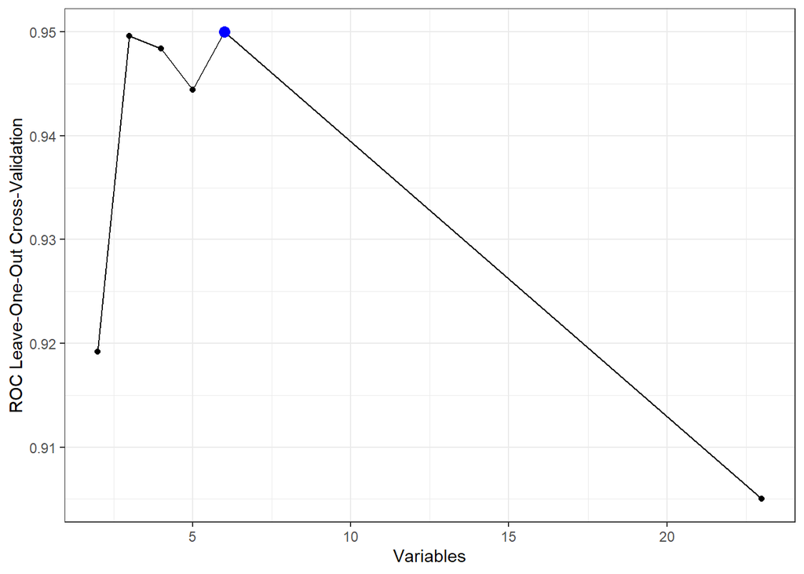

```r
# Gráfico del rendimiento según número de variables
ggplot(rfe_log) + theme_bw()
```

```r
# Ajustar el modelo final con los predictores ganadores ---
vars_elegidas <- predictors(rfe_log)
f_final <- as.formula(paste("EN ~", paste(vars_elegidas, collapse = " + ")))
modelo_final_glm <- glm(f_final, data = train_log, family = "binomial")
```

Ahora verificaremos las condiciones para este tipo de modelo: 1.Linealidad

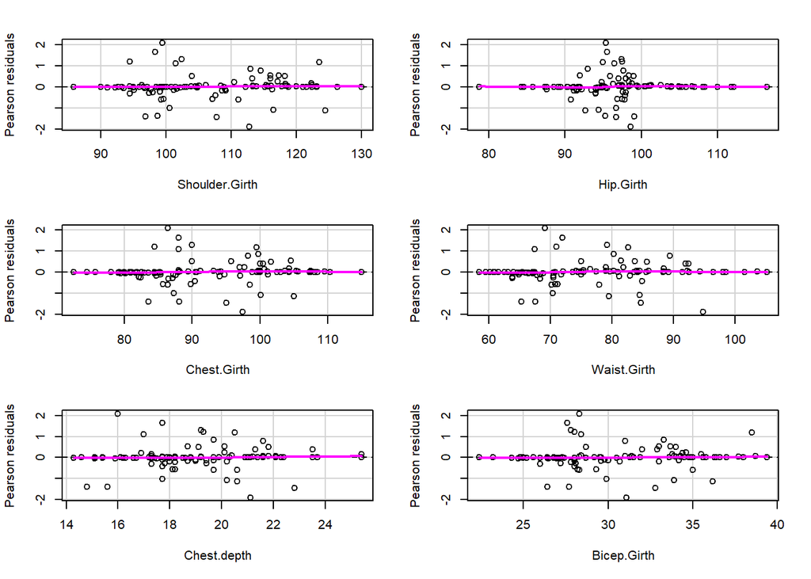

```
##                Test stat Pr(>|Test stat|)
## Shoulder.Girth    0.2566          0.61245
## Hip.Girth         0.8243          0.36393
## Chest.Girth       0.2417          0.62295
## Waist.Girth       3.2247          0.07253 .
## Chest.depth       1.3962          0.23736
## Bicep.Girth       0.4955          0.48149
## ---
## Signif. codes:  0 '***' 0.001 '**' 0.01 '*' 0.05 '.' 0.1 ' ' 1
```

```r
# Generamos los gráficos de residuos, desactivando el gráfico de ajustados (fitted=FALSE)
residualPlots(modelo_final_glm, fitted = FALSE)
```

Pr(>|Test stat|) muestra el p-value de la prueba de curvatura, todos los valores son mayores a 0.05, por lo que no existe evidencia suficiente para rechazar linealidad.

2. Independencia de los Residuos

```r
# 2. Verificación de Independencia (Durbin-Watson)
durbinWatsonTest(modelo_final_glm)
```

```
##  lag Autocorrelation D-W Statistic p-value
##    1     -0.08357644       2.16347   0.318
##  Alternative hypothesis: rho != 0
```

3. Multicolinealidad

```r
# 3. Verificación de Multicolinealidad
vif(modelo_final_glm)
```

```
## Shoulder.Girth      Hip.Girth    Chest.Girth    Waist.Girth    Chest.depth
##      21.681174       3.584207      22.319589       5.824575       3.144103
##    Bicep.Girth
##       8.636394
```

Se detectó multicolinealidad severa (VIF > 10) en las variables de contorno de pecho y hombros. Esto es esperable dado que son medidas que anátomicamente ya se encuentran correlacionadas. Esta condición no se cumple, puede deberse principalmente a que el modelo se consturyó utilizando las variables que maximizan el ROC y esto puede llevar a elegir variables que entreguen la misma información, haciendolo eficiente pero redundante.

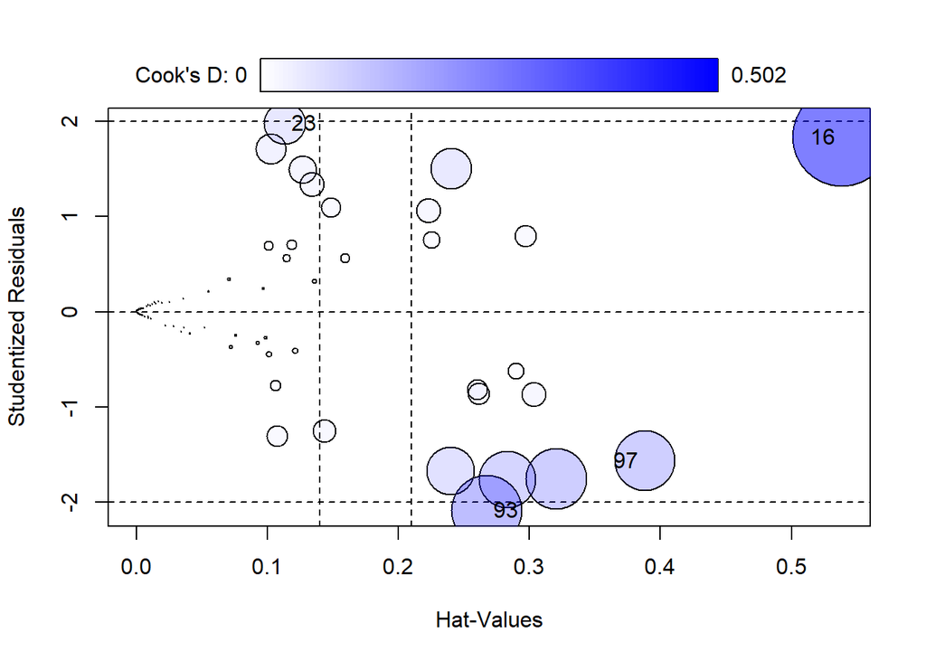

```
##      StudRes       Hat      CookD
## 23  1.977982 0.1130976 0.08949349
## 93 -2.090337 0.2672013 0.25632223
## 97 -1.567984 0.3881021 0.18938012
## 16  1.833259 0.5385647 0.50152811
```

```r
# 6. Verificación de Casos Influyentes
influencePlot(modelo_final_glm)
```

El análisis de influencia detectó observaciones críticas, específicamente el caso 16, el cual presenta una distancia de Cook elevada (0.501) y un alto apalancamiento (Hat > 0.5). El modelo es sensible a observaciones individuales.

Como conclusión de todas las verificaciones anteriores, se puede decir que el modelo no es confiable. Sin embargo, se pondrá a prueba en el conjunto de datos no vistos, para ver los resultados y su capacidad predictiva en comparación con los datos de entrenamiento.

```r
#5. Evaluación en conjunto de prueba)

# 1. Realizar predicciones de probabilidad y clase
probs_pru <- predict(modelo_final_glm, newdata = test_log, type = "response")
umbral <- 0.5
preds_pru <- ifelse(probs_pru > umbral, "Sobrepeso", "No.sobrepeso")
preds_pru <- factor(preds_pru, levels = c("No.sobrepeso", "Sobrepeso"))

# 2. Matriz de Confusión
# 'positive' debe ser la clase de interés (Sobrepeso)
mat_conf_pru <- confusionMatrix(preds_pru, test_log$EN, positive = "Sobrepeso")

# 3. Curva ROC y AUC
roc_pru <- roc(test_log$EN, probs_pru, levels = c("No.sobrepeso", "Sobrepeso"), direction = "<")

# 4. Impresión de resultados
cat("\n\nEvaluación del modelo (cjto. de prueba):\n")
```

```
##
##
## Evaluación del modelo (cjto. de prueba):
```

```r
cat("----------------------------------------\n")
print(mat_conf_pru[["table"]]) # Tabla cruzada
```

```
##               Reference
## Prediction     No.sobrepeso Sobrepeso
##   No.sobrepeso           21         4
##   Sobrepeso               4        21
```

```r
cat("\n")
```

```r
cat(sprintf(" Exactitud:     %.3f\n", mat_conf_pru[["overall"]]["Accuracy"]))
```

```
##  Exactitud:     0.840
```

```r
cat(sprintf(" Sensibilidad:  %.3f\n", mat_conf_pru[["byClass"]]["Sensitivity"]))
```

```
##  Sensibilidad:  0.840
```

```r
cat(sprintf(" Especificidad: %.3f\n", mat_conf_pru[["byClass"]]["Specificity"]))
```

```
##  Especificidad: 0.840
```

```r
cat(sprintf(" AUC:           %.3f\n", roc_pru$auc))
```

```
##  AUC:           0.936
```

```r
# Recuperamos métricas de entrenamiento (Promedios de la validación cruzada RFE)
best_size <- rfe_log$optsize
train_metrics <- rfe_log$results[rfe_log$results$Variables == best_size, ]

cat("\n\n--- Análisis de Sobreajuste (Entrenamiento vs Prueba) ---\n")
```

```
##
##
## --- Análisis de Sobreajuste (Entrenamiento vs Prueba) ---
```

```r
cat("Comparación de métricas clave:\n\n")
```

```
## Comparación de métricas clave:
```

```r
# 1. AUC
cat(sprintf("AUC Entrenam.:  %.3f  vs  Prueba: %.3f  | Dif: %.3f\n",
            train_metrics$ROC, roc_pru$auc, train_metrics$ROC - roc_pru$auc))
```

```
## AUC Entrenam.:  0.950  vs  Prueba: 0.936  | Dif: 0.014
```

```r
# 2. Sensibilidad
cat(sprintf("Sens. Entrenam.: %.3f  vs  Prueba: %.3f  | Dif: %.3f\n",
            train_metrics$Sens, mat_conf_pru[["byClass"]]["Sensitivity"], train_metrics$Sens - mat_conf_pru[["byClass"]]["Sensitivity"]))
```

```
## Sens. Entrenam.: 0.820  vs  Prueba: 0.840  | Dif: -0.020
```

```r
# 3. Especificidad
cat(sprintf("Spec. Entrenam.: %.3f  vs  Prueba: %.3f  | Dif: %.3f\n",
            train_metrics$Spec, mat_conf_pru[["byClass"]]["Specificity"], train_metrics$Spec - mat_conf_pru[["byClass"]]["Specificity"]))
```

```
## Spec. Entrenam.: 0.820  vs  Prueba: 0.840  | Dif: -0.020
```

```r
cat("\nConclusión del análisis:\n")
```

```
##
## Conclusión del análisis:
```

```r
diff_auc <- train_metrics$ROC - roc_pru$auc
if(diff_auc > 0.1) {
  cat("Existe una caída NOTABLE (>0.1) en el desempeño. Posible sobreajuste (Overfitting).\n")
} else {
  cat("Las métricas son similares. El modelo generaliza correctamente.\n")
}
```

```
## Las métricas son similares. El modelo generaliza correctamente.
```

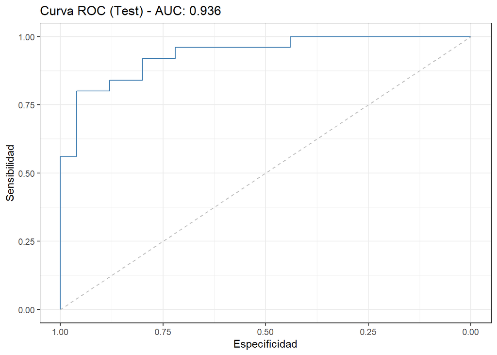

```r
# 5. Gráfico ROC Final
ggroc(roc_pru, color = "steelblue") +
  geom_segment(aes(x = 1, xend = 0, y = 0, yend = 1), color="grey", linetype="dashed") +
  theme_bw() +
  ggtitle(paste0("Curva ROC (Test) - AUC: ", round(roc_pru$auc, 3))) +
  xlab("Especificidad") + ylab("Sensibilidad")
```

De esta comparación podemos decir que el modelo no sufre de sobreajuste (overfitting). Ha aprendido patrones reales de la anatomía corporal en lugar de memorizar los datos de entrenamiento. A simple vista, tiene buenos indices de exactitud, sensibilidad y especificidad comparado con el de prueba. Sin embargo, ei bien el modelo demuestra un alto poder predictivo, no se considera estadísticamente confiable para fines inferenciales. El incumplimiento de los supuestos de no-multicolinealidad y la presencia de separación perfecta comprometen la interpretación de los coeficientes y la credibilidad del modelo.

### 6. Pronunciarse sobre la confiabilidad y capacidad predictiva de los modelos

A. Modelo RLM para Peso Confiabilidad: Baja. No cumple el supuesto de linealidad (curvatura en residuos) ni el de no-multicolinealidad (VIF críticos en Chest.Girth), lo que hace inestables sus coeficientes. Poder Predictivo: Bueno a pesar de las fallas teóricas, el error promedio (MAE) de 1.71 kg es bajo para el rango de peso adulto, indicando utilidad en la práctica.

B. Modelo RLM para IMC Confiabilidad: Moderada/Baja. Cumple homoscedasticidad e independencia, pero falla gravemente en multicolinealidad debido a la alta cantidad de predictores (VIF altos en Bicep.Girth y Forearm.Girth). Poder Predictivo: Alto. El MAE de 1.06 es excelente y la similitud entre métricas de entrenamiento y prueba confirma que generaliza correctamente.

C. Modelo Logístico para EN Confiabilidad: Baja. Presenta “separación perfecta” y multicolinealidad severa, lo que invalida la interpretación estadística de los coeficientes. Poder Predictivo: Alto. Con un AUC de 0.936 y Exactitud del 84% en el conjunto de prueba (sin sobreajuste respecto al entrenamiento), es altamente eficaz para clasificar el estado nutricional.

Los tres modelos comparten el mismo diagnóstico: la naturaleza correlacionada de las medidas usadas genera multicolinealidad, impidiendo que sean confiables para explicar relaciones causales (inferencia). Sin embargo, esta misma correlación permite que tengan un alto poder predictivo, validándolos como herramientas eficaces para estimación y clasificación en nuevos pacientes.